# Customer Report with Linear Regression and Classifier Models

#### 09.04.2023

Open research on customer report is a valuable tool for businesses to gain insights into their customers and make data-driven decisions. It is a very basic customer report that provides detailed information about a business's customers, including their demographics, behaviors, and preferences. This small types of information can be used to identify trends, target specific segments of the market, and optimise marketing campaigns. This report can also help businesses understand their customers' needs and develop new products and services that better meet those needs.

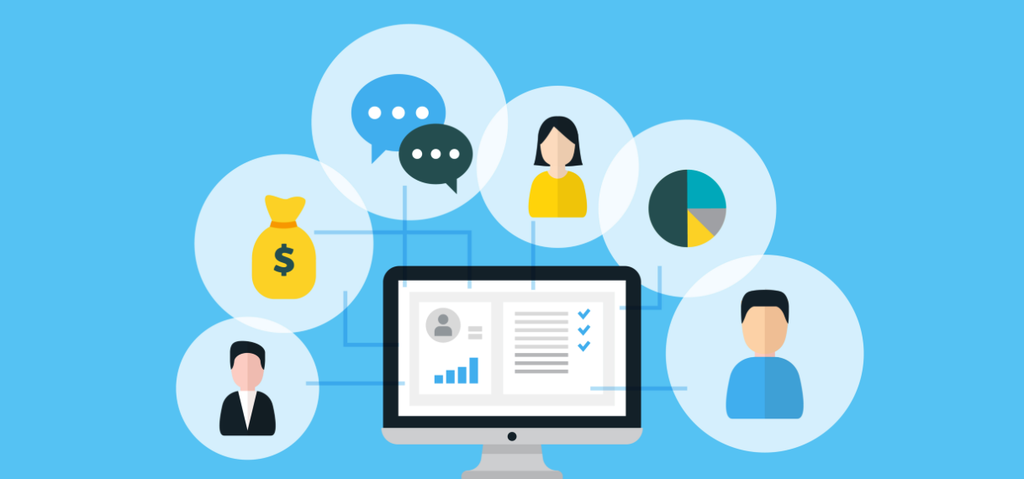

Hemant Thapa

### ML MODEL:

1. SIMPLE LINEAR REGRESSION
2. LOGISTIC REGRESSION
3. SUPPORT VECTOR CLASSIFIER
4. RANDOM FOREST CLASSIFIER
5. XGBOOST

### 1. LIBRARIES

```python
import pandas as pd
import numpy as np
import matplotlib.pyplot as plt
import seaborn as sns
```

### 2. LOADING DATASET

```python
df = pd.read_csv('https://raw.githubusercontent.com/harryworlds/Dataset_repository/main/Mall_Customers.csv')
```

### 3. DATA CLEANSING

```python
df.isnull().sum()
```

```
CustomerID                0
Genre                     0
Age                       0
Annual Income (k$)        0
Spending Score (1-100)    0
dtype: int64
```

```python
df.columns
```

```
Index(['CustomerID', 'Genre', 'Age', 'Annual Income (k$)',
       'Spending Score (1-100)'],
      dtype='object')
```

```python
df = df.rename(columns={"Annual Income (k$)": "Annual_Income"})
df = df.rename(columns={"Spending Score (1-100)":"Spending Score"})
df = df.rename(columns={"CustomerID":"Customer ID"})
```

```python
df.columns = df.columns.str.lower()
df.columns = df.columns.str.replace(" ", "_")
df.columns = df.columns.str.replace("-", "_")
df.columns = df.columns.str.replace("genre", "gender")
```

```python
df.shape
```

```
(200, 5)
```

```python
df.columns
```

```
Index(['customer_id', 'gender', 'age', 'annual_income', 'spending_score'], dtype='object')
```

### 4. FEMALE CUSTOMER ARE MORE COMAPRE TO MALE CUSTOMERS.

```python
df.gender.value_counts()
```

```
Female    112
Male       88
Name: gender, dtype: int64
```

#### 5. CATEGORICAL REPRESENTATION OF FEMALE & MALE CUSTOMER

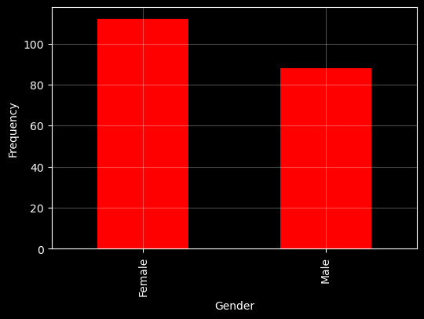

```python
plt.figure(figsize=(6,4))
df.gender.value_counts().plot.bar(color="red")
plt.xlabel("Gender")
plt.ylabel("Frequency")
plt.gca().grid(color='white', alpha=0.30)
plt.show()
plt.close()
```

#### 6. SCATTER PLOT BETWEEN ANNUAL INCOME AND AGE

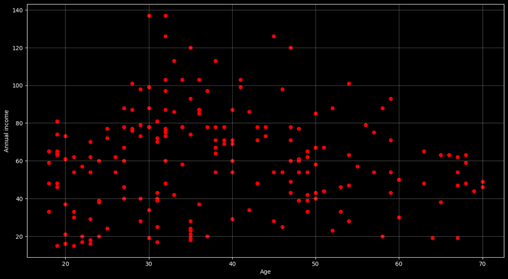

```python
plt.figure(figsize=(15,8))
plt.scatter(df.age,df['annual_income'], color="red")
plt.ylabel("Annual income")
plt.xlabel("Age")
plt.gca().grid(color='white', alpha=0.30)
plt.show()
```

### 7. LINEAR REGRESSION MODEL

```python
from sklearn.linear_model import LinearRegression
from sklearn.model_selection import train_test_split
```

```python
model = LinearRegression()
```

```python
y = df.annual_income.values.reshape(-1,1)
```

```python
x = df.age.values.reshape(-1,1)
```

```python
x_test, x_train, y_test, y_train = train_test_split(x,y, test_size=0.20, random_state=0)
```

```python
model.fit(x_train,y_train)
```

```
LinearRegression()
```

```python
y_pred = model.predict(x_test)
```

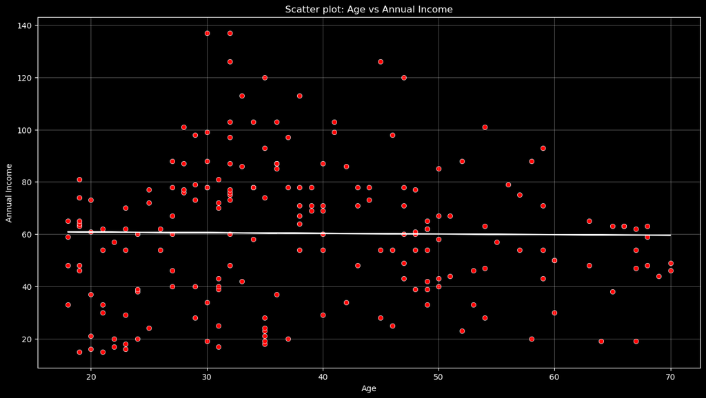

```python
plt.figure(figsize=(15,8))
sns.scatterplot(data=df, x='age', y='annual_income', color="red")
plt.plot(x_test,y_pred, color="white")
plt.xlabel('Age')
plt.ylabel('Annual Income')
plt.title('Scatter plot: Age vs Annual Income')
plt.gca().grid(color='white', alpha=0.30)
plt.show()
```

There is very low correlation between Age and Annual income in our dataset, which is nearly negligible.

### 8. CATEGORICAL REPRESENTATION OF AGE COUNT

```python
df.age.value_counts()
```

```
32    11
35     9
19     8
31     8
30     7
49     7
40     6
38     6
47     6
27     6
36     6
23     6
34     5
20     5
29     5
```

[output cut: 37 more lines]

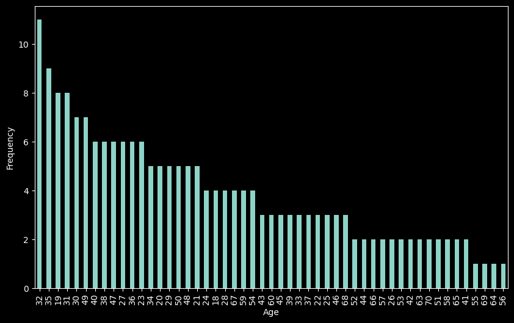

```python
plt.figure(figsize=(10,6))
df.age.value_counts().plot.bar()
plt.xlabel("Age")
plt.ylabel("Frequency")
plt.show()
plt.close()
```

Age 32 is the highest count of 11 and age 56 is the lowest count in our dataset

```python
df[:4]
```

|  | customer_id | gender | age | annual_income | spending_score |
| --- | --- | --- | --- | --- | --- |
| 0 | 1 | Male | 19 | 15 | 39 |
| 1 | 2 | Male | 21 | 15 | 81 |
| 2 | 3 | Female | 20 | 16 | 6 |
| 3 | 4 | Female | 23 | 16 | 77 |

```python
df.gender = df.gender.replace("Male", 1)
df.gender = df.gender.replace("Female", 0)
```

```python
df[:4]
```

|  | customer_id | gender | age | annual_income | spending_score |
| --- | --- | --- | --- | --- | --- |
| 0 | 1 | 1 | 19 | 15 | 39 |
| 1 | 2 | 1 | 21 | 15 | 81 |
| 2 | 3 | 0 | 20 | 16 | 6 |
| 3 | 4 | 0 | 23 | 16 | 77 |

```python
df['annual_income'].unique()
```

```
array([ 15,  16,  17,  18,  19,  20,  21,  23,  24,  25,  28,  29,  30,
        33,  34,  37,  38,  39,  40,  42,  43,  44,  46,  47,  48,  49,
        50,  54,  57,  58,  59,  60,  61,  62,  63,  64,  65,  67,  69,
        70,  71,  72,  73,  74,  75,  76,  77,  78,  79,  81,  85,  86,
        87,  88,  93,  97,  98,  99, 101, 103, 113, 120, 126, 137])
```

### 9. CATPLOT OF AGE & ANNUAL INCOME WITH RESPECT TO GENDER

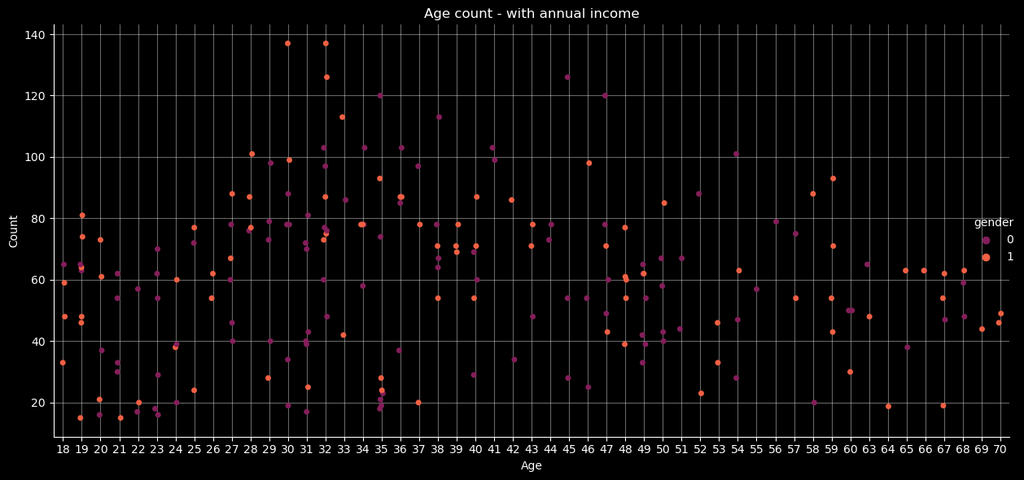

```python
plt.style.use('dark_background')
sns.catplot(x="age", y="annual_income", data=df, hue="gender", palette='rocket', height=6,aspect=2)
plt.title('Age count - with annual income')
plt.xlabel('Age')
plt.ylabel('Count')
plt.gca().grid(color='white', alpha=0.40)
plt.tight_layout()
plt.show()
```

### 10. LOGISTIC REGRESSION MODEL

```python
from sklearn.linear_model import LogisticRegression
from sklearn.model_selection import train_test_split
from sklearn.metrics import accuracy_score, classification_report
from sklearn.metrics import accuracy_score
```

```python
# Set a threshold to categorize spending_score. median
threshold = df['spending_score'].median()
```

```python
# Create a binary target variable: 1 for high spending, 0 for low spending
df['high_spending'] = (df['spending_score'] > threshold).astype(int)
```

```python
#features (X) and target (y)
X = df[['age', 'annual_income']]
y = df['high_spending']
```

```python
# Split the dataset into training and testing sets
X_train, X_test, y_train, y_test = train_test_split(X, y, test_size=0.2, random_state=0)
```

```python
model = LogisticRegression()
model.fit(X_train, y_train)
```

```
LogisticRegression()
```

```python
# Make predictions and evaluate the model
y_pred = model.predict(X_test)
print("Accuracy:", accuracy_score(y_test, y_pred))
print(classification_report(y_test, y_pred))
```

```
Accuracy: 0.775
              precision    recall  f1-score   support

           0       0.72      0.90      0.80        20
           1       0.87      0.65      0.74        20

    accuracy                           0.78        40
   macro avg       0.79      0.78      0.77        40
weighted avg       0.79      0.78      0.77        40
```

### 11. SUPPORT VECTOR CLASSIFIER

```python
df.gender = df.gender.replace("Male",1)
df.gender = df.gender.replace("Female",0)
```

```python
from sklearn.svm import SVC
from sklearn.preprocessing import StandardScaler
```

```python
#features (X) and target (y)
X = df[['age', 'annual_income']]
y = df['high_spending']
```

```python
#Good practice to scale the features for SVM
scaler = StandardScaler()
X = scaler.fit_transform(X)
```

```python
# Split the dataset into training and testing sets
X_train, X_test, y_train, y_test = train_test_split(X, y, test_size=0.2, random_state=0)
```

```python
# Create and train the SVM classifier
model = SVC()
model.fit(X_train, y_train)
```

```
SVC()
```

```python
# Make predictions and evaluate the model
y_pred = model.predict(X_test)
print("Accuracy:", accuracy_score(y_test, y_pred))
print(classification_report(y_test, y_pred))
```

```
Accuracy: 0.825
              precision    recall  f1-score   support

           0       0.84      0.80      0.82        20
           1       0.81      0.85      0.83        20

    accuracy                           0.82        40
   macro avg       0.83      0.82      0.82        40
weighted avg       0.83      0.82      0.82        40
```

### 12. RANDOM FOREST CLASSIFIER

```python
from sklearn.ensemble import RandomForestClassifier
from sklearn.metrics import classification_report
```

```python
#features (X) and target (y)
X = df[['age', 'annual_income']]
y = df['high_spending']
```

```python
# Split the dataset into training and testing sets
X_train, X_test, y_train, y_test = train_test_split(X, y, test_size=0.2, random_state=0)
```

```python
# Create and train the random forest classifier
model = RandomForestClassifier()
model.fit(X_train, y_train)
```

```
RandomForestClassifier()
```

```python
# Make predictions and evaluate the model
y_pred = model.predict(X_test)
accuracy = accuracy_score(y_test, y_pred)

print("Accuracy: ", accuracy)
```

```
Accuracy:  0.825
```

```python
print("Classification Report:")
print(classification_report(y_test, y_pred))
```

```
Classification Report:
              precision    recall  f1-score   support

           0       0.84      0.80      0.82        20
           1       0.81      0.85      0.83        20

    accuracy                           0.82        40
   macro avg       0.83      0.82      0.82        40
weighted avg       0.83      0.82      0.82        40
```

### 13. XGBOOST

```python
from xgboost import XGBClassifier
from sklearn.metrics import accuracy_score
```

```python
#features (X) and target (y)
X = df[['age', 'annual_income']]
y = df['high_spending']
```

```python
# Split the dataset into training and testing sets
X_train, X_test, y_train, y_test = train_test_split(X, y, test_size=0.2, random_state=42)
```

```python
# Create and train the XGBoost classifier
model = XGBClassifier()
model.fit(X_train, y_train)
```

```
XGBClassifier(base_score=None, booster=None, callbacks=None,
              colsample_bylevel=None, colsample_bynode=None,
              colsample_bytree=None, early_stopping_rounds=None,
              enable_categorical=False, eval_metric=None, feature_types=None,
              gamma=None, gpu_id=None, grow_policy=None, importance_type=None,
              interaction_constraints=None, learning_rate=None, max_bin=None,
              max_cat_threshold=None, max_cat_to_onehot=None,
              max_delta_step=None, max_depth=None, max_leaves=None,
              min_child_weight=None, missing=nan, monotone_constraints=None,
              n_estimators=100, n_jobs=None, num_parallel_tree=None,
              predictor=None, random_state=None, ...)
```

```python
# Make predictions and evaluate the model
y_pred = model.predict(X_test)
accuracy = accuracy_score(y_test, y_pred)
print("Accuracy: ", accuracy)
```

```
Accuracy:  0.725
```

```python
print("Classification Report:")
print(classification_report(y_test, y_pred))
```

```
Classification Report:
              precision    recall  f1-score   support

           0       0.80      0.70      0.74        23
           1       0.65      0.76      0.70        17

    accuracy                           0.73        40
   macro avg       0.73      0.73      0.72        40
weighted avg       0.74      0.72      0.73        40
```

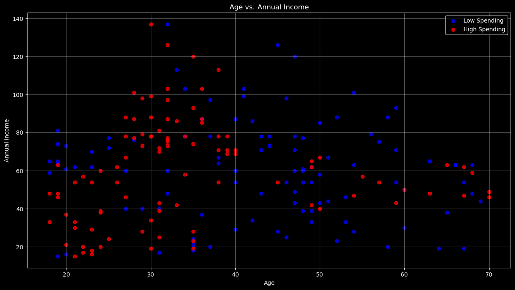

```python
plt.figure(figsize=(15,8))
plt.style.use('dark_background')
plt.scatter(df[df['high_spending'] == 0]['age'], df[df['high_spending'] == 0]['annual_income'], label='Low Spending', color='blue', alpha=0.8)
plt.scatter(df[df['high_spending'] == 1]['age'], df[df['high_spending'] == 1]['annual_income'], label='High Spending', color='red', alpha=0.8)
plt.title('Age vs. Annual Income')
plt.xlabel('Age')
plt.ylabel('Annual Income')
plt.legend()
plt.gca().grid(color='white', alpha=0.40)
plt.show()
```

The spending_score column is categorized into high and low spending based on a threshold value. The age and annual_income columns are used as features for the logistic regression model. Adjust the features, target variable, and threshold value based on your specific requirements.